# Classification methods applied to an imbalanced big dataset

## 6.6) `LDA` - Linear Discriminant Analysis:

Now `Linear discriminant analysis` will be applied. This algorithm is popular when dealing with a multiclass dependent variable, like our variable `symboling`.

It finds a linear combination of features that characterizes or separates two or more classes of objects.

In this case it will be applied with `repeat cross-validation`, `10 folds`, `repeated 3 times` and `down sampling` In this case as it is not based on `euclidean distance`, it can be applied to `train_cars` instead of `train_cars1`. Aditionally, the feature `make` will not be omitted, because this model can manage very well the `ordinal` variables with several levels.

### 6.6.1) Train the data

```r
 set.seed(16)
 ctrl_cv10 <- trainControl(method= "repeatedcv",
                           number = 10,
                           repeats = 3,
                           sampling= "down")
lda_model <- train(
   symboling ~ .,
   data = cars_train,
   method = "lda",
   trControl = ctrl_cv10)
 saveRDS(lda_model , "lda_model.rds")
```

Linear Discriminant Analysis

700001 samples 25 predictor 3 classes: ‘neutral’, ‘risky’, ‘secure’

No pre-processing Resampling: Cross-Validated (10 fold, repeated 3 times) Summary of sample sizes: 630001, 630002, 630001, 630000, 630000, 630001, … Addtional sampling using down-sampling

Resampling results:

Accuracy Kappa  
0.4973712 0.225034

### 6.6.2) Prediction on test sample

```r
 set.seed(16)
 lda_model_fitted <- predict(lda_model,
                               cars_test)
 saveRDS(lda_model_fitted, "lda_model_fitted.rds")
```

```r
 set.seed(16)
 lda_model_fitted_prob <- predict(lda_model,
                               cars_test,
                               type= "prob")
 saveRDS(lda_model_fitted_prob, "lda_model_fitted_prob.rds")
```

### 6.6.3) Results

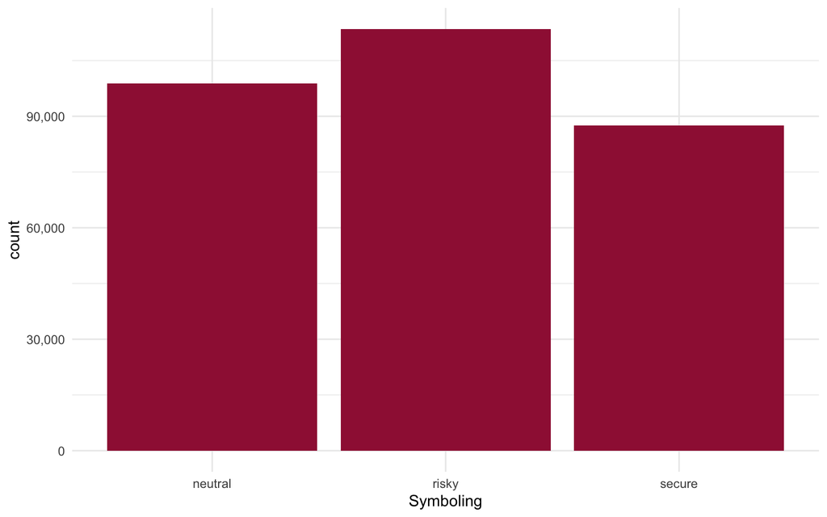

| lda_model_fitted | Freq |
| --- | --- |
| neutral | 98889 |
| risky | 113509 |
| secure | 87601 |

Most of the cars were predicted as `risky`, 113.509 cars.

Below we can find a table in order to compare the result on the test sample:

|  | neutral | risky | secure |
| --- | --- | --- | --- |
| neutral | 49984 | 39584 | 9321 |
| risky | 23677 | 80268 | 9564 |
| secure | 23405 | 44945 | 19251 |

Finally, we will apply the function `accuracy_multinom` in order to see the different measures of `accuracy` of our model:

| accuracy | balanced_accuracy | balanced_correctly_predicted |
| --- | --- | --- |
| 49.8345 | 50.22731 | 47.74548 |

| Multiclass.ROC |
| --- |
| 0.68485 |

The `ROC` obtained is similar to the `Multinomial Logistic Regression`.

## 6.7) `QDA` - Quadratic Discriminant Analysis:

Similarly to the case of `SVM` there are other similar algorithms that apply other kind of combination rather than `linear`, for example `quadratic`, this last will be applied in this case.

In this case it will be applied with `repeat cross-validation`, `10 folds`, `repeated 3 times` and `down sampling`, in this case as it is not based on `euclidean distance`, it can be applied to `train_cars` instead of `train_cars1`. Aditionally, the feature `make` will not be omitted, because this model can manage well the `ordinal` variables with several levels.

### 6.7.1) Train the data

```r
 set.seed(16)
 ctrl_cv10 <- trainControl(method= "repeatedcv",
                           number = 10,
                           repeats = 3,
                           sampling= "down")
qda_model <- train(
   symboling ~ .,
   data = cars_train,
   method = "qda",
   trControl = ctrl_cv10)
 saveRDS(qda_model , "qda_model.rds")
```

Quadratic Discriminant Analysis

700001 samples 25 predictor 3 classes: ‘neutral’, ‘risky’, ‘secure’

No pre-processing Resampling: Cross-Validated (10 fold, repeated 3 times) Summary of sample sizes: 630001, 630002, 630001, 630000, 630000, 630001, … Addtional sampling using down-sampling

Resampling results:

Accuracy Kappa  
0.5382359 0.269335

### 6.6.2) Prediction on test sample

```r
 set.seed(16)
 qda_model_fitted <- predict(qda_model,
                               cars_test)
 saveRDS(qda_model_fitted, "qda_model_fitted.rds")
```

```r
 set.seed(16)
 qda_model_fitted_prob <- predict(qda_model,
                               cars_test,
                               type= "prob")
 saveRDS(qda_model_fitted_prob, "qda_model_fitted_prob.rds")
```

### 6.6.3) Results

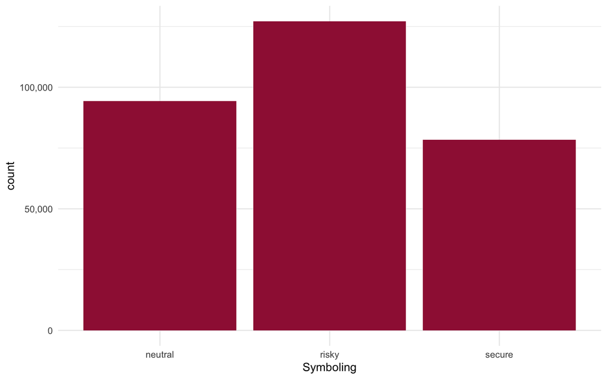

| qda_model_fitted | Freq |
| --- | --- |
| neutral | 94351 |
| risky | 127163 |
| secure | 78485 |

Most of the cars were predicted as `risky`, 127.163 cars.

Below we can find a table in order to compare the result on the test sample:

|  | neutral | risky | secure |
| --- | --- | --- | --- |
| neutral | 51702 | 34740 | 7909 |
| risky | 25727 | 90720 | 10716 |
| secure | 19637 | 39337 | 19511 |

Finally, we will apply the function `accuracy_multinom` in order to see the different measures of `accuracy` of our model:

| accuracy | balanced_accuracy | balanced_correctly_predicted |
| --- | --- | --- |
| 53.97785 | 53.15866 | 50.33285 |

| Multiclass.ROC |
| --- |
| 0.71601 |

The `ROC meausure` is the largest one, so this is one of the best models, as we cannot trust the `accuracy`

# 7) `Summary` and `conclusions`:

## 7.1) `Summary`:

| Model name | Accuracy | Bal. accuracy | Bal. correct. accuracy | ROC | Var. select. | CV | Fold | Resampling |
| --- | --- | --- | --- | --- | --- | --- | --- | --- |
| MLR | 60.67 | 42.94 | 57.93 | 0.68 | No | No | 0 | No |
| MLR -make | 59.32 | 41.15 | 57.40 | 0.66 | Yes | No | 0 | No |
| PMR | 60.67 | 42.94 | 57.94 | 0.68 | No | Yes | 5 | No |
| PMR no sam | 59.32 | 41.14 | 57.36 | 0.66 | No | Yes | 2 | No |
| PMR sam | 47.56 | 48.51 | 46.26 | 0.67 | No | Yes | 2 | Down |
| KNN | 45.13 | 34.76 | 34.90 | 0.54 | Yes | Yes | 3 | Down |
| LDA | 49.83 | 50.23 | 47.75 | 0.68 | No | Yes | 10 | Down |
| QDA | 53.98 | 53.16 | 50.33 | 0.72 | No | Yes | 10 | Down |

## 7.2) `Conclusions`:

- For the dataset `cars` the best `classification` model is `Quadratic Discriminant` with `repeated cross validation` and `down-sampling`
- In `imbalanced` data one cannot trust the `accuracy` to compare models, the model tends to predict the most common `class`, hence other kind of measures are recomended, in our case `ROC` was used
- `K nearest neighbors` and `support vector machine` are models that do not work very well with `multiclass` dependent variable, it would be better to use them in case of `binomial` depdent varaible
- Before applying demanding models, it is convenient to analize `ceteris paribus` what is expected to happen, in our case it was analized what will happen when `down-sampling` is applied
- `Computational time` matters, and it should be taken into consideration when applying `machine learning` models, hence the `data preparation` is really important in these cases. In certain instances it is recommended to `parallel` the process, when the algorithm allows to do it (`doParallel` and `doMC` packages can be used)
- In case of having a `big data` and `imbalance clases` it is really productive to use `down-sampling`, in terms of `computational time` and `performance` of the model
- When performing a `Machine Learning` analysis it is important to have enough memory in the system which would allow one to save the results

# 8) `References`:

- Class materials provided by Piotr Wójcik PhD at the course “Machine Learning 1”, University of Warsaw, 2020
- Photo source: https://unsplash.com/photos/FkJ3aNGeFMY
- https://machinelearningmastery.com/feature-selection-with-the-caret-r-package/
- https://machinelearningmastery.com/why-one-hot-encode-data-in-machine-learning/
- http://topepo.github.io/caret/index.html
- https://machinelearningmastery.com/compare-the-performance-of-machine-learning-algorithms-in-r/